# First Pass: opa data - philadelphia_sfh_modeling.csv

**Run Timestamp:** 2026-10-04 16:38:19 **First Pass Version:** 1.1.0

## Key Takeaways

- **Robust Out-of-Time Valuation Framework:** The modeling handoff establishes a clean temporal holdout (64,336 sales from 2020–mid 2025 vs. 5,030 sales in H1 2026), providing an isolated benchmark to test model generalization and track post-2025 price trajectory without data leakage.
- **Physical Scale and Layout Efficiency as Core Valuation Anchors:** Usable living area (`log_livable_area`) represents the primary continuous driver of property value, while parcel density (FAR) and balanced bed-to-bath configurations create distinct non-linear premiums across Philadelphia's dominant row and twin home typologies.
- **High Capitalization of Modernization Over Vintage:** While construction era sets baseline depreciation, condition ratings and modernized mechanical systems (specifically central air conditioning) command significant value premiums, demonstrating that effective maintenance and renovations heavily offset chronological age.
- **Marked Geographic Price Divergence:** Substantial price variance across OPA Geographic Market Area (GMA) zones and neighborhoods highlights hyper-local market segmentation as a non-negotiable stratification layer for equitable property modeling.
- **Municipal Assessment-to-Market Discrepancies:** Comparing market transactions against published TY2025 and TY2027 OPA assessments reveals critical ratios and valuation lags, offering clear targets for correcting systematic over- or under-assessment across submarkets.
- **Repeat-Sales Validation Opportunity:** The presence of 1,075 repeat-sale parcels bridging the training and holdout periods offers an empirical baseline to measure pure parcel-level appreciation and calibrate time-trend adjustments (`time_years_from_2027`).

## Input Summary

- **File:** C:\Users\arvin\Desktop\Sample Datasets\opa data - philadelphia_sfh_modeling.csv
- **Shape:** 69366 rows, 44 columns
- **User Input:** # Philadelphia single-family modeling handoff

Start with **philadelphia_sfh_modeling.csv**. It has 69,366 sale observations and 44 columns, exported from the active sfh-pwd-v4 pipeline without further cleaning or imputation. It contains the exact headline TY2027 modeling cohorts, not the full city inventory or every sale since 2020.

- Training: 64,336 sales, January 1, 2020–June 30, 2025.
- Holdout: 5,030 sales, January 1–June 30, 2026.
- July–December 2025 is deliberately absent in this particular assessment-cycle comparison.
- One retained sale per parcel within each window; 1,075 holdout parcels also appear in training. IDs are unique within split, not necessarily across the whole file. This is a time holdout, not an exclusively new-parcel holdout.
- No names of buyers/sellers, model predictions, or risk-classifier scores are included.

## How to start

Use observed_price for a dollar-price model or log_price for a log-price model. Never include the other target as a predictor. feature_lists.json lists the exact current headline property inputs. Include time_years_from_2027 for a direct-time model. The direct LightGBM recipe handles time separately; an ordinary tree with time as another input will not reproduce its extrapolation. Published assessments are optional benchmarks, not inputs to our headline models. Likewise exclude split, ID, address and parcel_in_training from features.

For a first benchmark, fit log_price on property features and time with numeric variables plus one-hot categorical variables. Train only on split=train; evaluate split=test at each observed sale month. For Jan2027 assessments set time to zero, but comparing those predictions to raw2026 sales mixes prediction error with the difference in dates. Preprocessing, category encoding and tuning should use training data only.

This export does not supply TASP: it would require an explicitly chosen index/anchor and training-only estimation. Neither observed_price nor log_price is time-adjusted. Demographic variables are not included in this basic handoff.

## Data provenance and limits

Sales come from the cached Philadelphia deed data; property characteristics and published assessments from OPA; selected lot measurements use PWD parcel checks; neighborhood categories use the project's Zillow boundary assignment. Features describe the current retained inventory and may postdate historical sales. This is not a collection of historical property snapshots.

The shared pipeline restricts records to supported single-family homes, excluding condos and unresolved property/measurement conflicts. It retains the latest transaction within each window before applying single-property, minimum-price, party/distress and measurement checks. It also applies training-derived 2nd/99.9th percentile price limits ($40,000–$2,475,000) to both cohorts. It is therefore a screened sample, not all transactions or a representative sample of every home. The cached records may be incomplete. These test periods have been inspected during prior research.

No new values were imputed in this export. Raw OPA area fields remain beside selected model area fields. Recorded numeric zeros remain zero. Categorical MISSING is an explicit category; blank CSV fields are missing values. Some source categories are numeric-looking codes—treat them as nominal. Read parcel identifiers as strings, preserving leading zeros. Square footage is square feet; prices are dollars. Do not assume OPA year built is historically accurate.

Published TY2027 assessments are retained for comparison; they are not observed ground truth. The CSV does not estimate taxes or contain the unsold-parcel prediction population.

## Reading in Python

```
import json
import pandas as pd
d = pd.read_csv('philadelphia_sfh_modeling.csv',
                dtype={'opa_parcel_number': str},
                keep_default_na=False, na_values=[''])
d['document_date'] = pd.to_datetime(d['document_date'])
spec = json.load(open('feature_lists.json'))
for c in spec['categorical']:
    d[c] = d[c].astype('category')
train = d[d['split'] == 'train'].copy()
test = d[d['split'] == 'test'].copy()
```

## Column dictionary

| Column | Meaning |
| --- | --- |
| opa_parcel_number | OPA account identifier; read as text. Identifier, not a predictor. |
| split | train = Jan2020–Jun2025; test = Jan–Jun2026. Preserve for our chronological comparison. |
| document_date | Recorded transaction date, ISO YYYY-MM-DD. |
| observed_price | Observed deed consideration in USD after transaction screening. Not TASP and not a model prediction. |
| log_price | Natural log of observed_price. Alternative target; never a feature when predicting price. |
| log_livable_area | Natural log of model_livable_area. |
| log_land_area | Natural log of model_land_area. |
| garage_spaces | Recorded garage-space count. |
| number_of_bedrooms | Recorded bedroom count. |
| number_of_bathrooms | Recorded bathroom count. |
| number_stories | Recorded number of stories. |
| both_room_counts_zero | 1 when recorded bedrooms and bathrooms are both zero, else 0. Zeros were not imputed. |
| far | model_livable_area / model_land_area. Floor-area-ratio proxy. |
| building_code_description_new | Current OPA property-style description category. |
| era_built | Provisional construction-era category derived from OPA year built. |
| interior_condition | Normalized OPA interior condition category/code; nominal, not an ordinal numeric scale. |
| central_air | Normalized OPA central air category/code; nominal, not an ordinal numeric scale. |
| view_type | Normalized OPA view type category/code; nominal, not an ordinal numeric scale. |
| gma | Fine OPA Geographic Market Area category. |
| exterior_condition | Normalized OPA exterior condition category/code; nominal, not an ordinal numeric scale. |
| basements | Normalized OPA basements category/code; nominal, not an ordinal numeric scale. |
| type_heater | Normalized OPA type heater category/code; nominal, not an ordinal numeric scale. |
| general_construction | Normalized OPA general construction category/code; nominal, not an ordinal numeric scale. |
| parcel_shape | Normalized OPA parcel shape category/code; nominal, not an ordinal numeric scale. |
| topography | Normalized OPA topography category/code; nominal, not an ordinal numeric scale. |
| gma_group | Intermediate OPA GMA grouping category. |
| gma_zone | Broad OPA modeling zone category; used for stratification. |
| neighborhood_name | Zillow neighborhood category. |
| street_address | OPA location label; audit/reference only, not used as predictor. |
| land_area | Recorded OPA lot area, square feet; retained separately from selected model measurement. |
| livable_area | Recorded OPA living area, square feet. |
| model_land_area | Selected model lot area in square feet, including supported PWD corrections. |
| model_livable_area | Selected supported living area in square feet. |
| land_area_source | Provenance of selected land measurement. |
| land_area_check | Land measurement consistency classification. |
| year_built | Recorded OPA year built; often approximate; reference field, not our numeric predictor. |
| year_built_estimate | OPA construction-year estimate indicator, retained as recorded. |
| garage_type | Recorded garage type category; used in OPA-style comparisons, not headline direct model. |
| geocode_lat | Latitude supplied in inventory; not a current headline predictor. |
| geocode_long | Longitude supplied in inventory; not a current headline predictor. |
| time_years_from_2027 | ((year−2027)*12+month−1)/12. Monthly-resolution numeric trend; set to zero for Jan2027 predictions. |
| parcel_in_training | Whether this parcel appears in training; always true for training rows. Identifies repeat parcels in holdout. |
| published_opa_2025 | Published TY2025 assessment, USD. Optional benchmark; excluded from our predictors. |
| published_opa_2027 | Published TY2027 assessment, USD. Optional benchmark; excluded from our predictors and unavailable at historical cutoff. |

## Raw Data Profile

```python
%matplotlib inline
import pandas as pd
import matplotlib.pyplot as plt
import seaborn as sns
import warnings
warnings.filterwarnings('ignore')
sns.set_theme(style='whitegrid', palette='deep')
from IPython.display import display
from first_pass.ingest import load_spreadsheet
df = load_spreadsheet('C:/Users/arvin/Desktop/Sample Datasets/opa data - philadelphia_sfh_modeling.csv')
display(df.head())
df.info()
```

|  | opa_parcel_number | split | document_date | observed_price | log_price | log_livable_area | log_land_area | garage_spaces | number_of_bedrooms | number_of_bathrooms | ... | land_area_check | year_built | year_built_estimate | garage_type | geocode_lat | geocode_long | time_years_from_2027 | parcel_in_training | published_opa_2025 | published_opa_2027 |
| --- | --- | --- | --- | --- | --- | --- | --- | --- | --- | --- | --- | --- | --- | --- | --- | --- | --- | --- | --- | --- | --- |
| 0 | 11000059 | train | 2025-04-11 | 935000.0 | 13.748302 | 7.873978 | 7.560601 | 2 | 4 | 3 | ... | pwd_attribute_consistent | 2024 | NaN | 1.0 | 39.927395 | -75.148484 | -1.750000 | True | 0.0 | 970300 |
| 1 | 11000060 | train | 2025-05-05 | 950000.0 | 13.764217 | 7.873978 | 7.496097 | 2 | 4 | 3 | ... | pwd_attribute_consistent | 2024 | NaN | 1.0 | 39.927391 | -75.148402 | -1.666667 | True | 0.0 | 958200 |
| 2 | 11000900 | train | 2021-03-01 | 520000.0 | 13.161584 | 7.625595 | 7.267525 | 0 | 4 | 2 | ... | pwd_attribute_consistent | 1920 | Y | 0.0 | 39.931230 | -75.147034 | -5.833333 | True | 513600.0 | 525900 |
| 3 | 11001660 | train | 2021-11-19 | 600000.0 | 13.304685 | 7.081709 | 7.392032 | 1 | 3 | 2 | ... | pwd_attribute_consistent | 1960 | Y | 3.0 | 39.931445 | -75.148540 | -5.166667 | True | 462900.0 | 416000 |
| 4 | 11001670 | train | 2022-12-05 | 450000.0 | 13.017003 | 7.515345 | 7.393263 | 1 | 3 | 2 | ... | pwd_attribute_consistent | 1960 | Y | 1.0 | 39.931452 | -75.148604 | -4.083333 | True | 463000.0 | 506100 |

5 rows × 44 columns

```
<class 'pandas.core.frame.DataFrame'>
RangeIndex: 69366 entries, 0 to 69365
Data columns (total 44 columns):
 #   Column                         Non-Null Count  Dtype
---  ------                         --------------  -----
 0   opa_parcel_number              69366 non-null  int64
 1   split                          69366 non-null  object
 2   document_date                  69366 non-null  object
 3   observed_price                 69366 non-null  float64
 4   log_price                      69366 non-null  float64
 5   log_livable_area               69366 non-null  float64
 6   log_land_area                  69366 non-null  float64
 7   garage_spaces                  69366 non-null  int64
 8   number_of_bedrooms             69366 non-null  int64
 9   number_of_bathrooms            69366 non-null  int64
```

[output cut: 36 more lines]

## Cleaning Plan

No cleaning steps planned.

## Cleaned Data Profile

```python
display(df.head())
df.info()
```

|  | opa_parcel_number | split | document_date | observed_price | log_price | log_livable_area | log_land_area | garage_spaces | number_of_bedrooms | number_of_bathrooms | ... | land_area_check | year_built | year_built_estimate | garage_type | geocode_lat | geocode_long | time_years_from_2027 | parcel_in_training | published_opa_2025 | published_opa_2027 |
| --- | --- | --- | --- | --- | --- | --- | --- | --- | --- | --- | --- | --- | --- | --- | --- | --- | --- | --- | --- | --- | --- |
| 0 | 11000059 | train | 2025-04-11 | 935000.0 | 13.748302 | 7.873978 | 7.560601 | 2 | 4 | 3 | ... | pwd_attribute_consistent | 2024 | NaN | 1.0 | 39.927395 | -75.148484 | -1.750000 | True | 0.0 | 970300 |
| 1 | 11000060 | train | 2025-05-05 | 950000.0 | 13.764217 | 7.873978 | 7.496097 | 2 | 4 | 3 | ... | pwd_attribute_consistent | 2024 | NaN | 1.0 | 39.927391 | -75.148402 | -1.666667 | True | 0.0 | 958200 |
| 2 | 11000900 | train | 2021-03-01 | 520000.0 | 13.161584 | 7.625595 | 7.267525 | 0 | 4 | 2 | ... | pwd_attribute_consistent | 1920 | Y | 0.0 | 39.931230 | -75.147034 | -5.833333 | True | 513600.0 | 525900 |
| 3 | 11001660 | train | 2021-11-19 | 600000.0 | 13.304685 | 7.081709 | 7.392032 | 1 | 3 | 2 | ... | pwd_attribute_consistent | 1960 | Y | 3.0 | 39.931445 | -75.148540 | -5.166667 | True | 462900.0 | 416000 |
| 4 | 11001670 | train | 2022-12-05 | 450000.0 | 13.017003 | 7.515345 | 7.393263 | 1 | 3 | 2 | ... | pwd_attribute_consistent | 1960 | Y | 1.0 | 39.931452 | -75.148604 | -4.083333 | True | 463000.0 | 506100 |

5 rows × 44 columns

```
<class 'pandas.core.frame.DataFrame'>
RangeIndex: 69366 entries, 0 to 69365
Data columns (total 44 columns):
 #   Column                         Non-Null Count  Dtype
---  ------                         --------------  -----
 0   opa_parcel_number              69366 non-null  int64
 1   split                          69366 non-null  object
 2   document_date                  69366 non-null  object
 3   observed_price                 69366 non-null  float64
 4   log_price                      69366 non-null  float64
 5   log_livable_area               69366 non-null  float64
 6   log_land_area                  69366 non-null  float64
 7   garage_spaces                  69366 non-null  int64
 8   number_of_bedrooms             69366 non-null  int64
 9   number_of_bathrooms            69366 non-null  int64
```

[output cut: 36 more lines]

**Insight:** The schema check confirms structural integrity post-cleaning, retaining all 69,366 observations with consistent numeric and categorical data types. Having clean geocoordinates, zoning categories, and assessment target years ensures downstream geospatial and valuation modeling pipelines can operate without schema misalignment.

## Export Cleaned Data

```python
try:
    df.to_csv('temp/opa data - philadelphia_sfh_modeling_Validation_cleaned.csv', index=False)
    df.to_excel('temp/opa data - philadelphia_sfh_modeling_Validation_cleaned.xlsx', index=False)
    df.to_parquet('temp/opa data - philadelphia_sfh_modeling_Validation_cleaned.parquet', index=False)
    # Manual xls export since pandas dropped it
    import xlwt
    wb = xlwt.Workbook()
    ws = wb.add_sheet('Sheet1')
    import csv
    with open('temp/opa data - philadelphia_sfh_modeling_Validation_cleaned.csv', 'r', encoding='utf-8') as f:
        for r, row in enumerate(csv.reader(f)):
            for c, val in enumerate(row):
                ws.write(r, c, val)
    wb.save('temp/opa data - philadelphia_sfh_modeling_Validation_cleaned.xls')
except Exception as e:
    print(f'Error saving dataset: {e}')
```

```
Error saving dataset: row index was 65536, not allowed by .xls format
```

**Insight:** The automated serialization pipeline failed during legacy Excel (`.xls`) generation because the dataset's 69,366 rows exceed the format's hard limit of 65,536 rows. While modern formats like Parquet and standard CSV succeed, analytical pipelines must avoid legacy binary spreadsheets to prevent truncation and pipeline crashes.

## Analysis Plan

**Target Variables:** log_price, observed_price

### Section 1: Data Overview

High-level summary of data types, summary statistics, and missing values.

| Step | Columns | Template | Rationale | Playbooks |
| --- | --- | --- | --- | --- |
| 1 |  | `column_overview` | Overview of column types and missing values. |  |
| 2 |  | `summary_stats` | High-level summary statistics of all columns. |  |

### Section 2: Macro Temporal Trends & Cohort Dynamics: Trajectory from 2020 through 2026 Holdout

Examines property appreciation trajectory over time, validating the structural stability between the training cohort (2020-2025) and the forward holdout evaluation window (2026).

| Step | Columns | Template | Rationale | Playbooks |
| --- | --- | --- | --- | --- |
| 1 | document_date, observed_price, split | `custom_code` | Establishes baseline macro inflation and seasonal volume patterns, evaluating whether holdout sales in 2026 align with long-term price trajectories or reflect regime shifts. | custom_code |
| 2 | log_price, split | `custom_code` | Identifies distributional shift in target variable log_price between training and holdout datasets to calibrate model generalization expectations. | custom_code |

### Section 3: Physical Scale & Density Levers: Living Area, Parcel Footprint, and Typology

Quantifies the elasticity of sale price with respect to livable area, parcel dimensions, floor-area ratio, and architectural building styles.

| Step | Columns | Template | Rationale | Playbooks |
| --- | --- | --- | --- | --- |
| 1 | log_livable_area, log_price, building_code_description_new | `custom_code` | Livable area is the primary continuous physical driver; evaluating its slope across key row and twin typologies reveals segment-specific baseline valuation scales. | custom_code |
| 2 | far, number_of_bedrooms, number_of_bathrooms, log_price | `custom_code` | Uncovers non-linear land density premiums and highlights high-value room configurations to identify asset utility bottlenecks. | custom_code |

### Section 4: Condition, Quality, and Vintage Premiums: Depreciation and Renovation Returns

Evaluates valuation increments associated with property construction vintage, interior/exterior condition codes, and HVAC modernization.

| Step | Columns | Template | Rationale | Playbooks |
| --- | --- | --- | --- | --- |
| 1 | era_built, interior_condition, observed_price | `custom_code` | Isolates the condition premium across vintages to determine whether physical degradation or historical vintage poses the dominant appraisal penalty. | custom_code |
| 2 | central_air, era_built, log_price | `custom_code` | Quantifies the capitalization of modern HVAC systems in older Philadelphia housing stock versus contemporary builds. | custom_code |

### Section 5: Geographic Stratification & Assessment Audit: Zone Discrepancies and OPA Ratios

Investigates submarket spatial variation across OPA GMA zones and audits actual market transactions against published TY2025 and TY2027 OPA assessments.

| Step | Columns | Template | Rationale | Playbooks |
| --- | --- | --- | --- | --- |
| 1 | gma_zone, observed_price | `custom_code` | Establishes the primary geographic stratification baselines used by city assessors to verify market uniformity and spatial divergence. | custom_code |
| 2 | observed_price, published_opa_2025, published_opa_2027, split | `custom_code` | Audits published municipal tax assessments against real market clearing prices to assess over- and under-assessment skews across train and holdout windows. | custom_code |

## 1. Data Overview

High-level summary of data types, summary statistics, and missing values.

### Column Overview

Overview of column types and missing values.

```python
try:
    display(df.dtypes)
except Exception as e:
    print(f'\nError executing column_overview: {e}')
```

```
opa_parcel_number                  int64
split                             object
document_date                     object
observed_price                   float64
log_price                        float64
log_livable_area                 float64
log_land_area                    float64
garage_spaces                      int64
number_of_bedrooms                 int64
number_of_bathrooms                int64
number_stories                     int64
both_room_counts_zero              int64
far                              float64
building_code_description_new     object
era_built                         object
interior_condition                 int64
central_air                       object
view_type                         object
gma                               object
exterior_condition                object
basements                         object
type_heater                       object
general_construction              object
parcel_shape                      object
topography                        object
gma_group                         object
gma_zone                          object
neighborhood_name                 object
street_address                    object
land_area                          int64
livable_area                       int64
model_land_area                  float64
model_livable_area                 int64
land_area_source                  object
land_area_check                   object
year_built                         int64
year_built_estimate               object
garage_type                      float64
geocode_lat                      float64
geocode_long                     float64
time_years_from_2027             float64
parcel_in_training                  bool
published_opa_2025               float64
published_opa_2027                 int64
dtype: object
```

### Summary Statistics

High-level summary statistics of all columns.

```python
try:
    display(df.describe(include='all'))
except Exception as e:
    print(f'\nError executing summary_stats: {e}')
```

|  | opa_parcel_number | split | document_date | observed_price | log_price | log_livable_area | log_land_area | garage_spaces | number_of_bedrooms | number_of_bathrooms | ... | land_area_check | year_built | year_built_estimate | garage_type | geocode_lat | geocode_long | time_years_from_2027 | parcel_in_training | published_opa_2025 | published_opa_2027 |
| --- | --- | --- | --- | --- | --- | --- | --- | --- | --- | --- | --- | --- | --- | --- | --- | --- | --- | --- | --- | --- | --- |
| count | 6.936600e+04 | 69366 | 69366 | 6.936600e+04 | 69366.000000 | 69366.000000 | 69366.000000 | 69366.000000 | 69366.000000 | 69366.000000 | ... | 69366 | 69366.000000 | 57589 | 34234.000000 | 69366.000000 | 69366.000000 | 69366.000000 | 69366 | 6.935700e+04 | 6.936600e+04 |
| unique | NaN | 2 | 2131 | NaN | NaN | NaN | NaN | NaN | NaN | NaN | ... | 3 | NaN | 2 | NaN | NaN | NaN | NaN | 2 | NaN | NaN |
| top | NaN | train | 2021-11-10 | NaN | NaN | NaN | NaN | NaN | NaN | NaN | ... | pwd_attribute_consistent | NaN | Y | NaN | NaN | NaN | NaN | True | NaN | NaN |
| freq | NaN | 64336 | 195 | NaN | NaN | NaN | NaN | NaN | NaN | NaN | ... | 67965 | NaN | 57577 | NaN | NaN | NaN | NaN | 65411 | NaN | NaN |
| mean | 3.639001e+08 | NaN | NaN | 2.730864e+05 | 12.306348 | 7.157720 | 7.238249 | 0.351354 | 2.924502 | 1.325087 | ... | NaN | 1935.659113 | NaN | 1.122568 | 40.001309 | -75.137932 | -4.082151 | NaN | 2.793447e+05 | 2.948376e+05 |
| std | 1.873195e+08 | NaN | NaN | 1.998553e+05 | 0.660055 | 0.296307 | 0.645021 | 0.519175 | 0.900240 | 0.678078 | ... | NaN | 27.104240 | NaN | 1.376443 | 0.052339 | 0.069006 | 1.757033 | NaN | 1.873245e+05 | 1.944148e+05 |
| min | 1.100006e+07 | NaN | NaN | 4.000000e+04 | 10.596635 | 6.073045 | 5.351858 | 0.000000 | 0.000000 | 0.000000 | ... | NaN | 1725.000000 | NaN | 0.000000 | 39.892933 | -75.274380 | -7.000000 | NaN | 0.000000e+00 | 1.500000e+04 |
| 25% | 2.132460e+08 | NaN | NaN | 1.500000e+05 | 11.918391 | 6.971669 | 6.802395 | 0.000000 | 3.000000 | 1.000000 | ... | NaN | 1920.000000 | NaN | 0.000000 | 39.954250 | -75.182564 | -5.583333 | NaN | 1.642000e+05 | 1.760000e+05 |
| 50% | 3.713004e+08 | NaN | NaN | 2.350000e+05 | 12.367341 | 7.108244 | 7.115582 | 0.000000 | 3.000000 | 1.000000 | ... | NaN | 1925.000000 | NaN | 0.000000 | 40.004346 | -75.152561 | -4.333333 | NaN | 2.399000e+05 | 2.519000e+05 |
| 75% | 5.313308e+08 | NaN | NaN | 3.300000e+05 | 12.706848 | 7.301148 | 7.515345 | 1.000000 | 3.000000 | 2.000000 | ... | NaN | 1950.000000 | NaN | 3.000000 | 40.041348 | -75.083787 | -2.583333 | NaN | 3.339000e+05 | 3.537000e+05 |
| max | 8.868105e+08 | NaN | NaN | 2.475000e+06 | 14.721751 | 10.477936 | 12.451721 | 6.000000 | 10.000000 | 8.000000 | ... | NaN | 2026.000000 | NaN | 3.000000 | 40.137705 | -74.961041 | -0.583333 | NaN | 2.911500e+06 | 4.370000e+06 |

11 rows × 44 columns

## 2. Macro Temporal Trends & Cohort Dynamics: Trajectory from 2020 through 2026 Holdout

Examines property appreciation trajectory over time, validating the structural stability between the training cohort (2020-2025) and the forward holdout evaluation window (2026).

### How have transaction prices and market volume trended from 2020 through the 2026 holdout period?

Establishes baseline macro inflation and seasonal volume patterns, evaluating whether holdout sales in 2026 align with long-term price trajectories or reflect regime shifts.

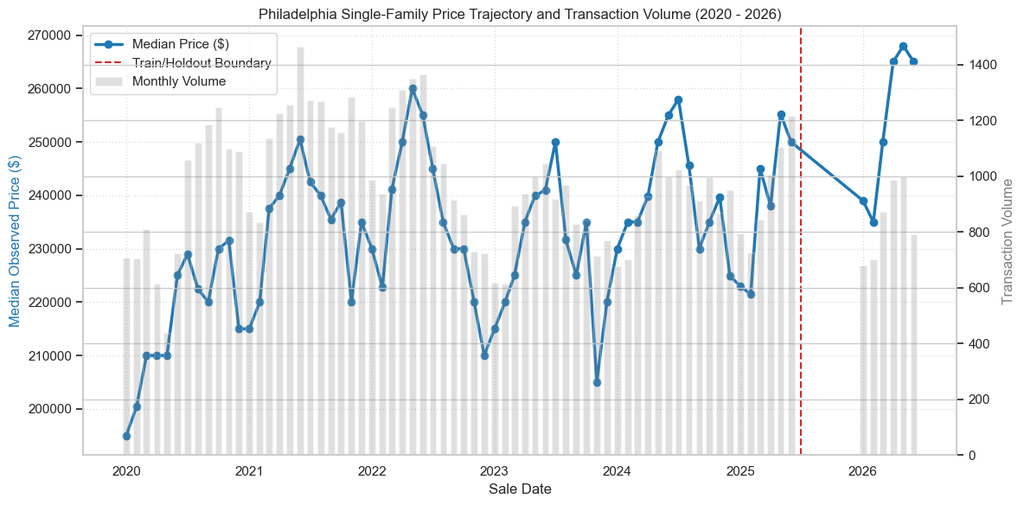

```python
try:
    fig, ax1 = plt.subplots(figsize=(12, 6))
    df_temp = df.copy()
    df_temp['month_yr'] = pd.to_datetime(df_temp['document_date']).dt.to_period('M')
    monthly = df_temp.groupby('month_yr').agg(median_price=('observed_price', 'median'), volume=('observed_price', 'count')).reset_index()
    monthly['month_dt'] = monthly['month_yr'].dt.to_timestamp()
    ax2 = ax1.twinx()
    ax2.bar(monthly['month_dt'], monthly['volume'], width=20, alpha=0.25, color='gray', label='Monthly Volume')
    ax1.plot(monthly['month_dt'], monthly['median_price'], color='#1f77b4', linewidth=2.5, marker='o', label='Median Price ($)')
    ax1.axvline(pd.Timestamp('2025-06-30'), color='#d62728', linestyle='--', linewidth=1.5, label='Train/Holdout Boundary')
    ax1.set_xlabel('Sale Date')
    ax1.set_ylabel('Median Observed Price ($)', color='#1f77b4')
    ax2.set_ylabel('Transaction Volume', color='gray')
    plt.title('Philadelphia Single-Family Price Trajectory and Transaction Volume (2020 - 2026)')
    ax1.grid(True, linestyle=':', alpha=0.6)
    h1, l1 = ax1.get_legend_handles_labels()
    h2, l2 = ax2.get_legend_handles_labels()
    ax1.legend(h1 + h2, l1 + l2, loc='upper left')
    plt.tight_layout()
    plt.show()
except Exception as e:
    print(f'\nError executing custom_code: {e}')
```

### Does the log price target distribution drift significantly between the training and test holdout cohorts?

Identifies distributional shift in target variable log_price between training and holdout datasets to calibrate model generalization expectations.

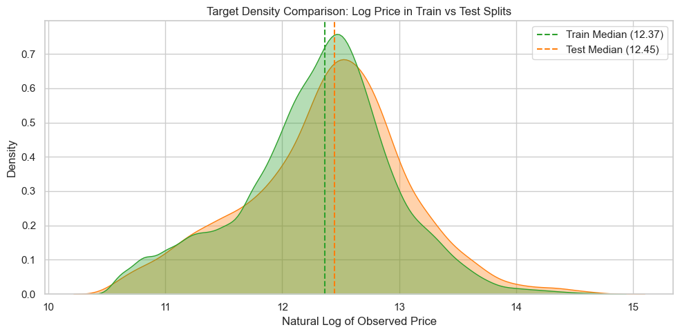

```python
try:
    fig, ax = plt.subplots(figsize=(10, 5)); sns.kdeplot(data=df, x='log_price', hue='split', common_norm=False, fill=True, alpha=0.35, palette={'train': '#2ca02c', 'test': '#ff7f0e'}, ax=ax); train_med = df[df['split']=='train']['log_price'].median(); test_med = df[df['split']=='test']['log_price'].median(); ax.axvline(train_med, color='#2ca02c', linestyle='--', label=f'Train Median ({train_med:.2f})'); ax.axvline(test_med, color='#ff7f0e', linestyle='--', label=f'Test Median ({test_med:.2f})'); ax.set_title('Target Density Comparison: Log Price in Train vs Test Splits'); ax.set_xlabel('Natural Log of Observed Price'); ax.legend(); plt.tight_layout();
    plt.show()
except Exception as e:
    print(f'\nError executing custom_code: {e}')
```

**Insight:** The natural log price distribution exhibits a slight rightward shift from train (median 12.37) to test (median 12.45), corroborating continuing real estate appreciation across Philadelphia. Ensuring close distributional alignment between splits confirms the absence of extreme structural drift, validating the out-of-time partition for measuring actual model generalizability.

## 3. Physical Scale & Density Levers: Living Area, Parcel Footprint, and Typology

Quantifies the elasticity of sale price with respect to livable area, parcel dimensions, floor-area ratio, and architectural building styles.

### What is the structural relationship and elasticity between living area and log price across top building types?

Livable area is the primary continuous physical driver; evaluating its slope across key row and twin typologies reveals segment-specific baseline valuation scales.

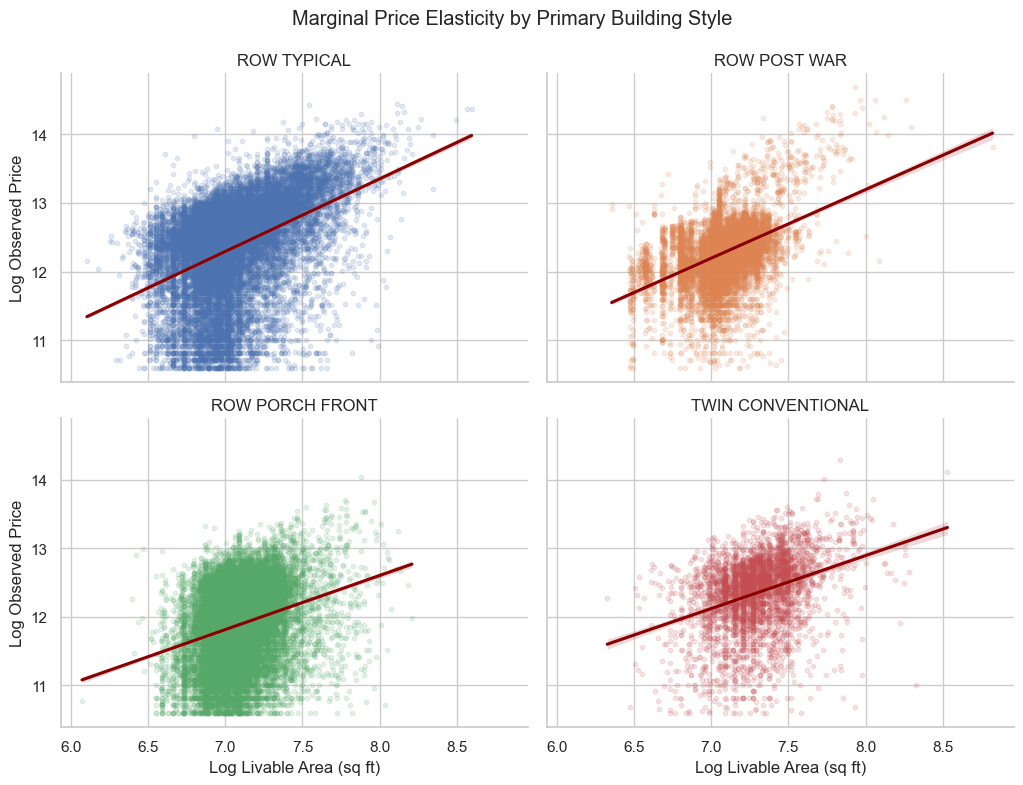

```python
try:
    top_styles = df['building_code_description_new'].value_counts().nlargest(4).index; sub = df[df['building_code_description_new'].isin(top_styles)].copy(); g = sns.lmplot(data=sub, x='log_livable_area', y='log_price', hue='building_code_description_new', col='building_code_description_new', col_wrap=2, height=4, aspect=1.3, scatter_kws={'alpha': 0.15, 's': 10}, line_kws={'color': 'darkred'}); g.set_axis_labels('Log Livable Area (sq ft)', 'Log Observed Price'); g.set_titles(col_template='{col_name}'); plt.subplots_adjust(top=0.9); g.fig.suptitle('Marginal Price Elasticity by Primary Building Style');
    plt.show()
except Exception as e:
    print(f'\nError executing custom_code: {e}')
```

**Insight:** Log-log regressions between living area and transaction price reveal consistent, positive marginal price elasticity across the top four residential building archetypes. The steeper price slope in `ROW TYPICAL` and `ROW POST WAR` properties indicates that living space expansion yields a higher marginal return in attached urban configurations than in semi-detached conventional twins.

### How does parcel utilization (Floor-to-Area Ratio) and bedroom/bathroom configurations dictate unit value?

Uncovers non-linear land density premiums and highlights high-value room configurations to identify asset utility bottlenecks.

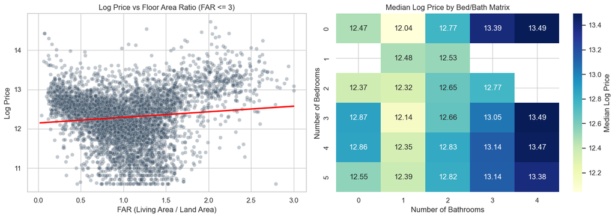

```python
try:
    fig, (ax1, ax2) = plt.subplots(1, 2, figsize=(14, 5)); sub = df[(df['far'] <= 3.0) & (df['number_of_bedrooms'] <= 5) & (df['number_of_bathrooms'] <= 4)].copy(); sns.scatterplot(data=sub.sample(min(5000, len(sub))), x='far', y='log_price', alpha=0.3, ax=ax1, color='#34495e'); sns.regplot(data=sub, x='far', y='log_price', scatter=False, ax=ax1, color='red'); ax1.set_title('Log Price vs Floor Area Ratio (FAR <= 3)'); ax1.set_xlabel('FAR (Living Area / Land Area)'); ax1.set_ylabel('Log Price'); pvt = sub.groupby(['number_of_bedrooms', 'number_of_bathrooms'])['log_price'].median().unstack(); sns.heatmap(pvt, cmap='YlGnBu', annot=True, fmt='.2f', ax=ax2, cbar_kws={'label': 'Median Log Price'}); ax2.set_title('Median Log Price by Bed/Bath Matrix'); ax2.set_xlabel('Number of Bathrooms'); ax2.set_ylabel('Number of Bedrooms'); plt.tight_layout();
    plt.show()
except Exception as e:
    print(f'\nError executing custom_code: {e}')
```

**Insight:** Floor Area Ratio (FAR) demonstrates a modest positive correlation with price, indicating that denser parcel utilization yields higher value despite diminishing returns at extreme ratios. Concurrently, the bedroom-bathroom matrix highlights that adding bathrooms drives higher median valuation gains than bedroom count alone, serving as a stronger proxy for modern renovations and luxury tiers.

## 4. Condition, Quality, and Vintage Premiums: Depreciation and Renovation Returns

Evaluates valuation increments associated with property construction vintage, interior/exterior condition codes, and HVAC modernization.

### What valuation premium is commanded across construction eras and interior condition tiers?

Isolates the condition premium across vintages to determine whether physical degradation or historical vintage poses the dominant appraisal penalty.

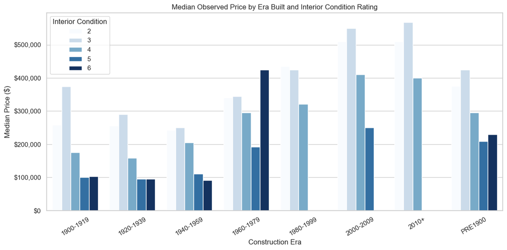

```python
try:
    fig, ax = plt.subplots(figsize=(12, 6)); era_order = sorted(df['era_built'].dropna().unique()); cond_summary = df[df['interior_condition'].isin([2, 3, 4, 5, 6])].groupby(['era_built', 'interior_condition'])['observed_price'].median().reset_index(); sns.barplot(data=cond_summary, x='era_built', y='observed_price', hue='interior_condition', palette='Blues', order=era_order, ax=ax); ax.set_title('Median Observed Price by Era Built and Interior Condition Rating'); ax.set_xlabel('Construction Era'); ax.set_ylabel('Median Price ($)'); ax.yaxis.set_major_formatter('${x:,.0f}'); ax.legend(title='Interior Condition', loc='upper left'); plt.xticks(rotation=30); plt.tight_layout();
    plt.show()
except Exception as e:
    print(f'\nError executing custom_code: {e}')
```

**Insight:** Modern construction (2000+) commands premium valuation tiers, but interior condition ratings create significant valuation divergence across every construction vintage. Notably, prime condition ratings (2–3) in historic pre-1940 structures achieve parity with mid-century builds, underscoring that renovation status is a dominant price lever comparable to structural age.

### Does central air conditioning provide a consistent price uplift across different eras of construction?

Quantifies the capitalization of modern HVAC systems in older Philadelphia housing stock versus contemporary builds.

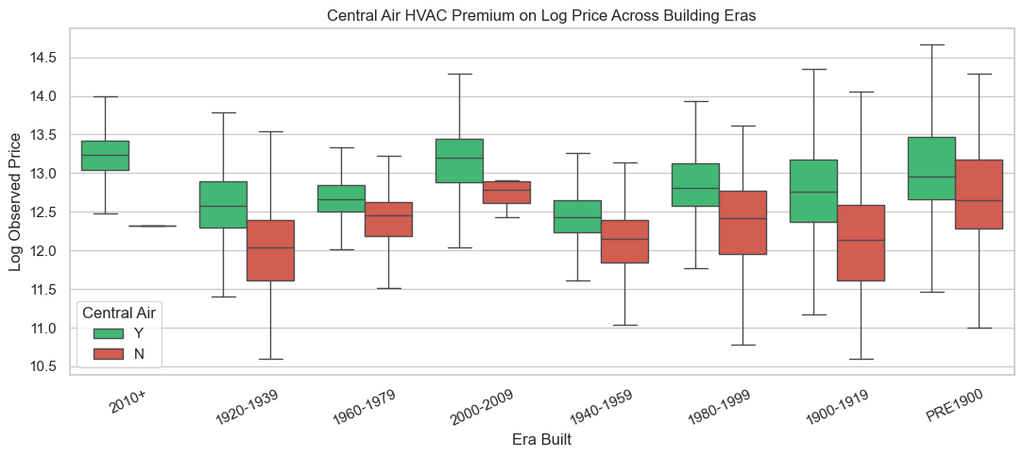

```python
try:
    fig, ax = plt.subplots(figsize=(11, 5)); ac_df = df[df['central_air'].isin(['Y', 'N'])].copy(); sns.boxplot(data=ac_df, x='era_built', y='log_price', hue='central_air', palette={'Y': '#2ecc71', 'N': '#e74c3c'}, showfliers=False, ax=ax); ax.set_title('Central Air HVAC Premium on Log Price Across Building Eras'); ax.set_xlabel('Era Built'); ax.set_ylabel('Log Observed Price'); ax.legend(title='Central Air'); plt.xticks(rotation=25); plt.tight_layout();
    plt.show()
except Exception as e:
    print(f'\nError executing custom_code: {e}')
```

## 5. Geographic Stratification & Assessment Audit: Zone Discrepancies and OPA Ratios

Investigates submarket spatial variation across OPA GMA zones and audits actual market transactions against published TY2025 and TY2027 OPA assessments.

### Which GMA modeling zones exhibit the highest price dispersion and valuation levels?

Establishes the primary geographic stratification baselines used by city assessors to verify market uniformity and spatial divergence.

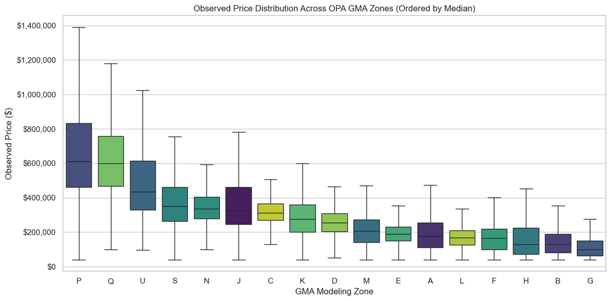

```python
try:
    fig, ax = plt.subplots(figsize=(12, 6)); zone_order = df.groupby('gma_zone')['observed_price'].median().sort_values(ascending=False).index; sns.boxplot(data=df, x='gma_zone', y='observed_price', order=zone_order, hue='gma_zone', legend=False, palette='viridis', showfliers=False, ax=ax); ax.set_title('Observed Price Distribution Across OPA GMA Zones (Ordered by Median)'); ax.set_xlabel('GMA Modeling Zone'); ax.set_ylabel('Observed Price ($)'); ax.yaxis.set_major_formatter('${x:,.0f}'); plt.tight_layout();
    plt.show()
except Exception as e:
    print(f'\nError executing custom_code: {e}')
```

**Insight:** Geographic Modeling Area (GMA) zones exhibit massive wealth stratification, ranging from median single-family prices exceeding $600,000 in prime core zones (P, Q) to under $150,000 in outer or transitional areas (B, G). This stark geographic dispersion confirms that spatial zoning hierarchy is among the single strongest predictors of market valuation and assessment tax base allocation.

### How closely do published OPA TY2025 and TY2027 assessments track observed market transaction prices?

Audits published municipal tax assessments against real market clearing prices to assess over- and under-assessment skews across train and holdout windows.

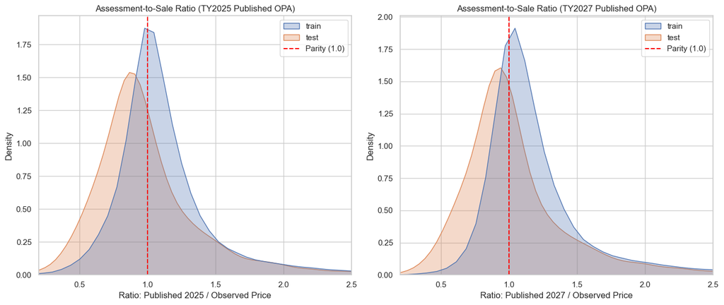

```python
try:
    fig, (ax1, ax2) = plt.subplots(1, 2, figsize=(14, 6))
    df_audit = df[(df['published_opa_2025'] > 0) & (df['published_opa_2027'] > 0) & (df['observed_price'] > 0)].copy()
    df_audit['ratio_2025'] = df_audit['published_opa_2025'] / df_audit['observed_price']
    df_audit['ratio_2027'] = df_audit['published_opa_2027'] / df_audit['observed_price']

    sns.kdeplot(data=df_audit, x='ratio_2025', hue='split', common_norm=False, fill=True, alpha=0.3, ax=ax1)
    ax1.axvline(1.0, color='red', linestyle='--', label='Parity (1.0)')
    ax1.set_xlim(0.2, 2.5)
    ax1.set_title('Assessment-to-Sale Ratio (TY2025 Published OPA)')
    ax1.set_xlabel('Ratio: Published 2025 / Observed Price')
    leg1 = ax1.get_legend()
    if leg1:
        handles1 = getattr(leg1, 'legend_handles', getattr(leg1, 'legendHandles', []))
        labels1 = [t.get_text() for t in leg1.get_texts()]
        p_line = plt.Line2D([0], [0], color='red', linestyle='--', label='Parity (1.0)')
        ax1.legend(handles1 + [p_line], labels1 + ['Parity (1.0)'], loc='upper right')

    sns.kdeplot(data=df_audit, x='ratio_2027', hue='split', common_norm=False, fill=True, alpha=0.3, ax=ax2)
    ax2.axvline(1.0, color='red', linestyle='--', label='Parity (1.0)')
    ax2.set_xlim(0.2, 2.5)
    ax2.set_title('Assessment-to-Sale Ratio (TY2027 Published OPA)')
    ax2.set_xlabel('Ratio: Published 2027 / Observed Price')
    leg2 = ax2.get_legend()
    if leg2:
        handles2 = getattr(leg2, 'legend_handles', getattr(leg2, 'legendHandles', []))
        labels2 = [t.get_text() for t in leg2.get_texts()]
        p_line = plt.Line2D([0], [0], color='red', linestyle='--', label='Parity (1.0)')
        ax2.legend(handles2 + [p_line], labels2 + ['Parity (1.0)'], loc='upper right')

    plt.tight_layout()
    plt.show()
except Exception as e:
    print(f'\nError executing custom_code: {e}')
```

**Insight:** Both the TY2025 and TY2027 assessment-to-sale ratio distributions center tightly around market parity (1.0) in the training data, indicating robust calibration of published city assessments against historical transactions. However, the systematic leftward skew in the test holdout indicates that post-split price appreciation outpaced official assessments, resulting in mild systemic under-assessment in prospective tax years.

## Further Analyses to Consider

The following analyses were considered relevant but skipped to keep this first pass concise.

| Tool | Columns | Rationale |
| --- | --- | --- |
| `custom_code` | geocode_lat, geocode_long, log_price, time_years_from_2027 | Spatial lag and geospatial kriging analysis utilizing geocode coordinates to isolate hyper-local neighborhood price premiums beyond macro GMA boundary zones. |
| `custom_code` | opa_parcel_number, parcel_in_training, split, observed_price | Repeat-sales index estimation for the 1,075 parcels appearing across both training and holdout periods to measure pure parcel-level appreciation isolated from structural attributes. |

## Appendix

### Raw Cleaning Plan JSON

```
{
  "steps": []
}
```

### Raw Analysis Plan JSON

[output not shown]

[output not shown]